# P1: Testando um Fenômeno de Percepção

Saulo de Souza Guerra Ferreira de Castro

13 de janeiro de 2017

## Estatística: A Ciência das Escolhas

A especificação detalhada do projeto pode ser encontrada no seguinte link: https://docs.google.com/document/d/10g8o19RnFlT5YujBS3c6FbJ_qooOODlXWAbLR8rnAAY/edit

### Questões para Investigação

#### Qual é a nossa variável independente? Qual é a nossa variável dependente?

A variável independente é tipo do conjunto de palavras lidas (condição), que pode ser congruente ou incongruente.

Já a variável dependente é o tempo de resposta para identificar a cor do conjunto de palavras.

#### Qual seria um conjunto apropriado de hipóteses para essa tarefa? Que tipo de teste estatístico você espera executar? Justifique suas escolhas.

Considerando que uma das teorias por trás do teste sugere que o cérebro leva menos tempo reconhecendo padrões de palavras do que reconhecendo padrões de cores, podemos nos perguntar se o tempo médio de resposta no teste das palavras incongruentes é maior do que das palavras congruentes, ou se o tempo médio não apresenta diferenças em relação ao teste das palavras congruentes. Portanto, considerando que:

- µc é o tempo médio de resposta dos participantes no teste com o conjunto de palavras congruentes
- µi é o tempo médio de resposta dos participantes no teste com o conjunto de palavras incongruentes

Podemos definir as seguintes hipóteses em função da diferença das médias:

- `H0: µc - µi = 0` (não há diferença entre os tempos médios)
- `HA: µc - µi < 0` (a diferença entre os tempos médios é menor que zero)

Para verificar as hipóteses, será necessário um **teste unicaldal**, pois a hipótese alternativa é de que a diferença do tempo médio na condição congruente e da condição incongruente seria menor do que zero, ou seja, o tempo médio na condição incongruente é maior do que na condição congruente.

No presente caso, não temos os parâmetros da população, apenas de amostras de ambos os casos (congruentes e incongruentes). Sendo assim, por compararmos amostras, é mais adequado o **uso do teste T**.

Por se tratar de duas amostras para condições diferentes, **usaremos o teste T pareado para amostras dependentes.**

#### Reporte alguma estatística descritiva em relação a esse conjunto de dados. Inclua, pelo menos, uma medida de tendência central de pelo menos uma medida de variabilidade.

Tabela com estatísticas descritivas:

```r
dados <- read.csv('P1-data.csv') %>%
  gather(condicao, tempo)

estatisticas.descritivas <- dados %>%
  group_by(condicao) %>%
  summarise(n = n(),
            mediana = median(tempo),
            media = mean(tempo),
            desvio_padrao = sd(tempo),
            variancia = var(tempo))

estatisticas.descritivas
```

```
## # A tibble: 2 x 6
##      condicao     n mediana    media desvio_padrao variancia
##         <chr> <int>   <dbl>    <dbl>         <dbl>     <dbl>
## 1   Congruent    24 14.3565 14.05113      3.559358  12.66903
## 2 Incongruent    24 21.0175 22.01592      4.797057  23.01176
```

#### Forneça uma ou duas visualizações que mostre a distribuição da amostra de dados. Escreva uma ou duas sentenças sobre o que você observou do gráfico ou gráficos.

No gráfico de boxplot podemos observar a visível diferença entre as medianas. Observamos também a ocorrência de possíveis outliers nos tempos na condição incongruente.

Já no histograma e no gráfico de densidade, podemos observar uma visível separação entre as médias das amostras, o que nos sugere que o tempo de resposta na condição incongruente possa ser significativamente maior.

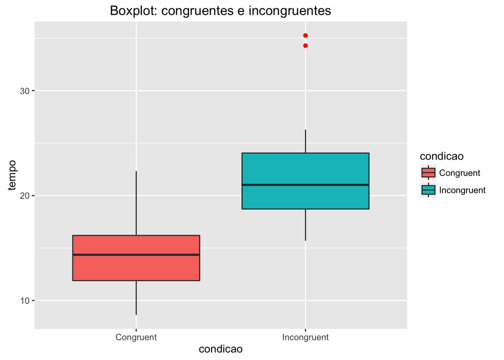

```r
ggplot(dados, aes(y = tempo, x = condicao, fill = condicao)) +
  geom_boxplot(outlier.colour = 'red') +
  ggtitle("Boxplot: congruentes e incongruentes")
```

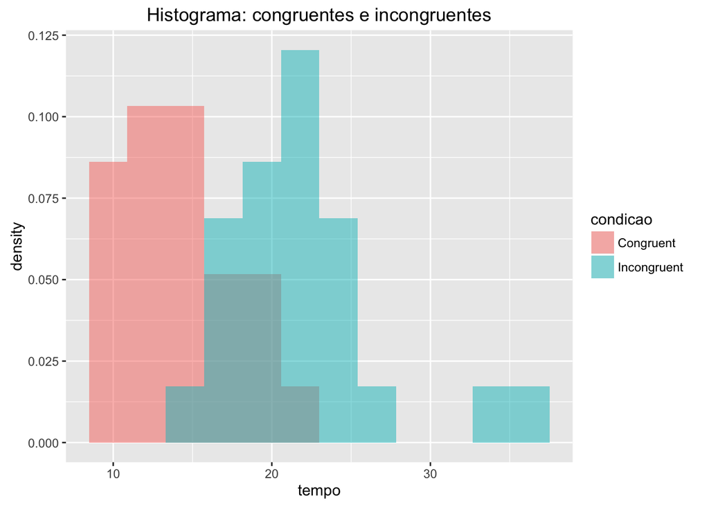

```r
ggplot(dados, aes(x = tempo, fill = condicao)) +
  geom_histogram(bins = 12, alpha = 0.5, aes(y = ..density..), position = 'identity') +
  ggtitle("Histograma: congruentes e incongruentes")
```

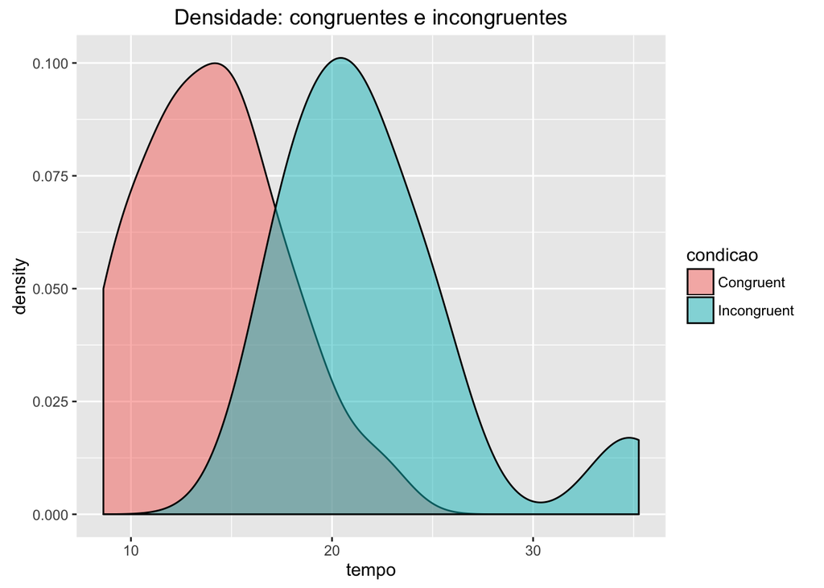

```r
ggplot(dados, aes(x = tempo, fill = condicao)) +
  geom_density(alpha = 0.5) +
  ggtitle("Densidade: congruentes e incongruentes")
```

#### Agora desempenhe o teste estatístico e reporte seus resultados. Qual seu nível de confiança e o valor estatístico crítico? Você rejeitou a hipótese nula ou falhou ao tentar rejeitá-la? Encontre uma conclusão em relação ao experimento da tarefa. Os resultados estão de acordo com suas expectativas?

Os testes serão realizados considerando intervalo de confiança de 95% (`α = 0.05`). Tendo a amostra com `23 graus de liberdade`, temos um t crítico para teste unicaldal de -1.714 (à esquerda pois HA: µc - µi < 0).

```r
dados <- read.csv('P1-data.csv')

calculo <- dados %>%
  mutate(diferenca = Congruent - Incongruent) %>%
  select(diferenca) %>%
  summarise(desvio_dif = sd(diferenca),
            media_dif = mean(diferenca),
            graus_liberdade = n()-1,
            erro_padrao_dif = desvio_dif/sqrt(n()),
            t = (media_dif - 0)/erro_padrao_dif)

calculo
```

```
##   desvio_dif media_dif graus_liberdade erro_padrao_dif         t
## 1   4.864827 -7.964792              23       0.9930286 -8.020707
```

Como resultado, temos a estatística `t = -8.021`, muito mais à esquerda que o `t crítico = -1.714`, o que nos permite rejeitar a hipótese nula de que µc - µi = 0.

Portanto, é possível afirmar (estatísticamente significante com nível de significância de 0.05) que os testes realizados com o grupo de palavras na condição incongruente levam mais tempo, em média `7.965` segundos, do que os teste realizados com o grupo na condição congruente. Em outras palavras, o tempo de resposta da condição congruente é menor do que da condição incongruente, conforme esperado pela teoria do esfeito stroop.

Para validar os resultados, os testes serão repetidos utilizando a função `t.test` do R, com os seguintes parâmetros:

- Por ser um t-test pareado, será avaliada a diferença das médias dos tempos da condição congruente e incongruente: `x = dados$Congruent, y = dados$Incongruent`
- Por ser um teste unicaldal (à esquerda), a hipotese alternativa é se a diferença é menor que zero: `alternative = "less"`
- A hipótese nula considera que a diferença das médias seria zero: `mu = 0`
- O tipo do t-teste é pareado: `paired = TRUE`
- O intervalo de confiança escolhido é de 95%: `conf.level = .95`

```r
t.test(x = dados$Congruent, y = dados$Incongruent,
        alternative = "less",
        mu = 0,
        paired = TRUE,
        conf.level = 0.95)
```

```
##
##  Paired t-test
##
## data:  dados$Congruent and dados$Incongruent
## t = -8.0207, df = 23, p-value = 2.052e-08
## alternative hypothesis: true difference in means is less than 0
## 95 percent confidence interval:
##       -Inf -6.262868
## sample estimates:
## mean of the differences
##               -7.964792
```

Percebe-se que os resultados são os mesmos. Desse cáclulo podemos avaliar ainda o p-valor bastante baixo, corroborando a decisão de rejeitar a hipótese nula.

#### Opcional: O que você acha que é responsável pelo efeito observado? Consegue pensar em uma alternativa ou tarefa similar que resultaria em um efeito parecido?

Segundo o artigo sobre efeito stroop na wikipedia, há algumas teorias que tenta explicar o fenômeno:

- Velocidade de processamento: a velocidade de processamento do cérebro é maior para reconhecimento de palavras do que cores
- Atenção seletiva: o reconhecimento de cores requer mais atenção do que reconhecimento de palavras
- Automaticidade: como resultado habitual da leitura, o cérebro automaticamente reconhece primeiro o padrão de palavras do que o padrão de cores.

### Referências

[Stroop Effect](https://en.wikipedia.org/wiki/Stroop_effect)

Valor-p

[Teste t de Student](https://pt.wikipedia.org/wiki/Teste_t_de_Student)